# Illustrative Example: Applying the Semiparametric Marginal Regression for Clustered Competing Risks Data with Misclassified Causes of Failure

Theofanis Balanos[^1]

Giorgos Bakoyannis[^2]

Constantin T. Yiannoutsos[^3]

In this short document, we present an example illustrating how to use our proposed Semiparametric Marginal Regression Method for Clustered Competing Risks Data with Misclassified Causes of Failure.

## Step 1 – Generate external validation dataset

We start by generating a simulated external **validation dataset** for modeling misclassification probabilities in **clustered competing-risks data**. The simulation mechanism follows the framework of *Mpofu et al.* (2020) for the double-sampling pseudo-likelihood approach but is extended here to incorporate **clustering** and **informative cluster size (ICS)**, following the ideas of *Zhou et al.* (2023). This design induces correlation among individuals within clusters through shared frailty terms, while cluster sizes depend on frailty values to induce ICS.

The resulting external dataset represents a **partially validated sample** (i.e., true causes are observed for roughly 50% of subjects). This dataset is used to **estimate the parameters of the misclassification model**, capturing how misclassification depends on time and covariates. The externally estimated misclassification probabilities are then **applied to the main analysis dataset** when fitting the proposed *semiparametric marginal regression model*.

The data-generation procedure is contained in a separate R script, `simulate_data.R`, included in the same repository folder. This script defines three main misclassification scenarios:

1. Unidirectional misclassification
2. Bidirectional misclassification (equal probabilities)
3. Bidirectional misclassification (unequal probabilities)

Below, we load this simulation script, generate an **external validation dataset** under the **bidirectional (equal)** case (`cause_num = 2`), and inspect the first few rows of one example dataset.

```r
#--- Generate a list of external validation datasets --------------------------

# Load data-generation script (extends Mpofu et al. 2020 to clustered setting)
source("simulate_data.R")

# Arguments:
# n           : number of datasets to generate
# n_clusters  : number of clusters per dataset
# cause_num   : misclassification scenario
#               1 = uni-directional
#               2 = bi-directional (equal probabilities)
#               3 = bi-directional (unequal probabilities)
# ds          : proportion double-sampled (validation indicator)

external_data_list <- data_list(
  n = 1,                # number of replicate datasets
  n_clusters = 50,      # number of clusters to simulate
  cause_num = 2,        # bidirectional misclassification (equal)
  ds = 0.5              # only 50% validated
)

# Select one dataset for demonstration
dat_external <- external_data_list[[1]]

# Display first few rows of the simulated external dataset
head(dat_external)
```

```
##   d1 d2          t          x        z1           z2 s r d1_obs d2_obs c_obs c
## 1  1  0 0.46248886 0.46248886 0.3702111 -0.553151770 0 0      1      0     1 1
## 2  0  1 0.46875381 0.46875381 0.2742269  0.129854929 0 0      1      0     1 2
## 3  0  1 0.36564405 0.36564405 0.8480131 -0.223852496 0 0      1      0     1 2
## 4  1  0 0.57621841 0.57621841 0.3322625  0.996600527 0 0      1      0     1 1
## 5  1  0 0.77901237 0.77901237 0.5372611 -0.085477246 1 1      1      0     1 1
## 6  1  0 0.08737887 0.08737887 0.5819751 -0.004261981 0 0      0      1     2 1
##   id cluster_id Mi
## 1  1          1 34
## 2  2          1 34
## 3  3          1 34
## 4  4          1 34
## 5  5          1 34
## 6  6          1 34
```

### Variable descriptions

Each simulated dataset generated by `simulate_data.R` contains the following variables.

| Variable | Description |
| --- | --- |
| **id** | Subject identifier (unique across all clusters). |
| **cluster_id** | Cluster identifier, denoting subjects belonging to the same cluster. |
| **Mi** | Cluster size, representing the number of subjects within each cluster. Cluster size is informative, depending on the cluster-level frailty. |
| **t** | True event time $T$. |
| **x** | Observed follow-up time (minimum of event or censoring time). |
| **c** | True cause of failure (1 = cause 1, 2 = cause 2, 0 = censored). |
| **c_obs** | Observed (possibly misclassified) cause of failure $C^{*}$. |
| **d1** | Indicator that the *true* cause of failure is 1 $(C=1)$. |
| **d2** | Indicator that the *true* cause of failure is 2 $(C=2)$. |
| **d1_obs** | Indicator that the *observed* cause of failure is 1 $(C^{*}=1)$. |
| **d2_obs** | Indicator that the *observed* cause of failure is 2 $(C^{*}=2)$. |
| **z1** | Continuous covariate 1 (Uniform(0, 1)). |
| **z2** | Continuous covariate 2 (Normal(0, 1)). |
| **s** | Double-sampling indicator (1 = subject selected for validation sample, 0 = not selected). |
| **r** | Indicator that the *true cause* is observed (1 = true cause known, 0 = missing). |

#### Note

All variables are fully simulated and serve only illustrative purposes.

## Step 2 – Estimate misclassification probabilities

Next, we apply the pseudo-likelihood estimation procedure of *Mpofu et al.* (2020), extended here to accommodate **clustering** and **informative cluster size (ICS)**, to the **external validation dataset** generated in Step 1. The clustered extension is implemented through **inverse cluster-size weighting (1/Mᵢ)** to address ICS and **GEE with a working independence correlation structure and a sandwich variance estimator** to account for within-cluster dependence.

This step estimates the parameters of the logistic-regression models for the predictive values and the misclassification probabilities. The estimated coefficients ($\hat{\gamma}_{n'}$) describe how covariates $(t, z_1, z_2)$ affect the probability of misclassifying one cause as another within clusters, and the estimated variance matrices ($\hat{\Omega}_{n'}$) quantify their uncertainty. Both quantities will later be used in Step 7 to perform cluster-bootstrap inference that incorporates uncertainty in the externally estimated misclassification parameters.

The estimation functions are defined in the external script `pseudo_likelihood_estimation_Mpofu.R`, which adapts the original Mpofu et al. (2020) approach to the clustered setting.

```r
#--- Load Mpofu et al. (2020) pseudo-likelihood estimation functions ----------
source("pseudo_likelihood_estimation_Mpofu.R")
```

### | Probability of observing cause 2 given true cause 1

In this case, we estimate the probability of observing cause 2 when the true cause of failure is 1; that is,
$$P(C^{*}=2 \mid C=1,\, T,\, Z)$$
representing misclassification from cause 1 → 2, where $T = t$ denotes the event time and $Z = (z_1, z_2)$ represents the subject-specific covariates.

```r
#--- Perform pseudo-likelihood estimation for cause 1 -> 2 --------------------
model_fit_example1 <- misclass_ps_est(dat = dat_external,
                                      true_out = "c",
                                      surr_out = "c_obs",
                                      out_interest = 1,
                                      formula_pred_val = ~ t + z1 + z2,
                                      formula_mis = ~ t + z1 + z2,
                                      ds_var = "r")

# Display estimated coefficients and standard errors
model_fit_example1$test_summary
```

```
##
## z test of coefficients:
##
##              Estimate Std. Error  z value  Pr(>|z|)
## (Intercept) -0.563568   0.017420 -32.3520 < 2.2e-16 ***
## t           -0.695858   0.112009  -6.2125 5.213e-10 ***
## z1           0.646379   0.027861  23.2004 < 2.2e-16 ***
## z2          -0.517205   0.024425 -21.1748 < 2.2e-16 ***
## ---
## Signif. codes:  0 '***' 0.001 '**' 0.01 '*' 0.05 '.' 0.1 ' ' 1
```

```r
# Point estimates (gamma-hat) and variance matrix (Omega-hat)
# These will be reused later for the gamma-variability bootstrap step.
gamma_hat_21  <- model_fit_example1$parEst
Omega_hat_21  <- model_fit_example1$varEst
```

### | Probability of observing cause 1 given true cause 2

Here, we estimate the probability of observing cause 1 when the true cause of failure is 2; that is,
$$P(C^{*}=1 \mid C=2,\, T,\, Z),$$
representing misclassification from cause 2 → 1, where $T = t$ denotes the event time and $Z = (z_1, z_2)$ represents the subject-specific covariates.

```r
#--- Perform pseudo-likelihood estimation for cause 2 -> 1 --------------------
model_fit_example2 <- misclass_ps_est(dat = dat_external,
                                      true_out = "c",
                                      surr_out = "c_obs",
                                      out_interest = 2,
                                      formula_pred_val = ~ t + z1 + z2,
                                      formula_mis = ~ t + z1 + z2,
                                      ds_var = "r")

# Display estimated coefficients and standard errors
model_fit_example2$test_summary
```

```
##
## z test of coefficients:
##
##               Estimate Std. Error  z value Pr(>|z|)
## (Intercept) -0.7742286  0.0323248 -23.9516   <2e-16 ***
## t           -0.0031045  0.0551380  -0.0563   0.9551
## z1           0.9407577  0.0459129  20.4901   <2e-16 ***
## z2          -0.6212655  0.0090346 -68.7650   <2e-16 ***
## ---
## Signif. codes:  0 '***' 0.001 '**' 0.01 '*' 0.05 '.' 0.1 ' ' 1
```

```r
# Point estimates (gamma-hat) and variance matrix (Omega-hat)
# These will be reused later for the gamma-variability bootstrap step.
gamma_hat_12  <- model_fit_example2$parEst
Omega_hat_12  <- model_fit_example2$varEst
```

## Step 3 – Generate main analysis dataset

In this step, we generate a **main dataset** representing the study cohort in which the true causes of failure are *not observed*. Only the misclassified causes ($C^{*}$) are available for analysis.

This dataset will later be analyzed using the proposed **semiparametric marginal regression method**, incorporating the **externally estimated misclassification probabilities** obtained in Step 2.

The same clustered simulation procedure used for the external validation data (see `simulate_data.R`) is employed here, but we now set the **double-sampling proportion** (`ds = 0`) so that no subjects have their true causes observed. Clustering and ICS are again induced through the frailty-based mechanism, ensuring dependence among subjects within clusters and an informative cluster-size distribution.

```r
#--- Generate the main (analysis) dataset -------------------------------------

# Note: simulate_data.R was already loaded in Step 1; re-sourcing is not required.

# Create one main dataset with no internal validation (ds = 0)
main_data_list <- data_list(
  n = 1,                 # number of replicate datasets
  n_clusters = 50,       # number of clusters
  cause_num = 2,         # bidirectional equal misclassification
  ds = 0.0               # no double-sampling (true causes unobserved)
)

dat_main <- main_data_list[[1]]

# Display first few rows of the main dataset
head(dat_main)
```

```
##   d1 d2          t          x        z1         z2 s r d1_obs d2_obs c_obs c id
## 1  0  1 0.16641149 0.16641149 0.7151819 -0.1668011 0 0      0      1     2 2  1
## 2  0  1 0.18759644 0.18759644 0.4711652 -0.4993493 0 0      0      1     2 2  2
## 3  0  1 0.11037090 0.11037090 0.1186688 -0.1784551 0 0      0      1     2 2  3
## 4  0  1 0.05466842 0.05466842 0.9186223  0.3593736 0 0      0      1     2 2  4
## 5  0  1 0.05395982 0.05395982 0.1750421  0.9068321 0 0      1      0     1 2  5
## 6  0  1 0.06007062 0.06007062 0.8177827  0.6964748 0 0      0      1     2 2  6
##   cluster_id  Mi
## 1          1 118
## 2          1 118
## 3          1 118
## 4          1 118
## 5          1 118
## 6          1 118
```

#### Note

All variables are defined as in Step 1.

## Step 4 – Compute misclassification probabilities for the main dataset

We now compute the estimated misclassification probabilities for each subject in the **main analysis dataset** using the misclassification models fitted on the external validation dataset (Step 2).

Specifically,

- $p_{21} = P(C^{*}=2 \mid C=1, T,\, Z)$: probability that true cause 1 is observed as 2
- $p_{12} = P(C^{*}=1 \mid C=2, T,\, Z)$: probability that true cause 2 is observed as 1

For Step 5 (point estimation), it is sufficient to call `predict()` directly on the fitted Mpofu models. However, for the cluster-bootstrap step in Step 7, we will need to recompute these probabilities using *perturbed* draws $\tilde{\gamma}_{n'}^{(b)} \sim N(\hat{\gamma}_{n'},\, \hat{\Omega}_{n'})$. To support both use cases consistently, we also define a small helper function `mis_prob()` that computes the predicted probability directly from a coefficient vector and the covariate matrix.

```r
#--- Step 4: Compute predicted misclassification probabilities -----------------

# Extract Mpofu model objects from Step 2
mod_21 <- model_fit_example1$model_miscl   # C=1 -> observed as 2
mod_12 <- model_fit_example2$model_miscl   # C=2 -> observed as 1

# Point-estimate predictions for the main analysis (Step 5)
dat_main$p21 <- predict(mod_21, newdata = dat_main, type = "response")
dat_main$p12 <- predict(mod_12, newdata = dat_main, type = "response")

#--- Helper: compute logistic predictions from a raw coefficient vector --------
# Used in Step 7 to apply perturbed gamma draws to bootstrap samples.
mis_prob <- function(gamma_vec, newdata, formula_mis = ~ t + z1 + z2) {
  X  <- model.matrix(formula_mis, data = newdata)   # design matrix incl. intercept
  lp <- as.numeric(X %*% gamma_vec)                  # linear predictor
  plogis(lp)                                         # back-transform to [0,1]
}

# Sanity check: the helper reproduces predict() within numerical tolerance.
stopifnot(
  max(abs(mis_prob(coef(mod_21), dat_main) - dat_main$p21)) < 1e-10,
  max(abs(mis_prob(coef(mod_12), dat_main) - dat_main$p12)) < 1e-10
)

# Display first few rows with misclassification probabilities
head(dat_main[, c("t", "z1", "z2", "p12", "p21")])
```

```
##            t        z1         z2       p12       p21
## 1 0.16641149 0.7151819 -0.1668011 0.5004238 0.4673421
## 2 0.18759644 0.4711652 -0.4993493 0.4946676 0.4672243
## 3 0.11037090 0.1186688 -0.1784551 0.3653855 0.3842927
## 4 0.05466842 0.9186223  0.3593736 0.4666835 0.4517255
## 5 0.05395982 0.1750421  0.9068321 0.2362938 0.2774811
## 6 0.06007062 0.8177827  0.6964748 0.3922711 0.3924581
```

## Step 5 – Apply the proposed semiparametric regression method

In this step, we apply the proposed **semiparametric marginal regression estimator** to the **main analysis dataset**. This method uses the externally estimated misclassification probabilities $p_{12}$ and $p_{21}$ obtained in Step 4 to correct for outcome misclassification in the cause-specific hazard estimation. The function further accounts for **informative cluster size (ICS)** through **inverse cluster-size weighting** $(1 / M_i)$ in the estimating equations. Within-cluster dependence is not modeled directly during estimation; valid inference under within-cluster dependence is achieved later via the **cluster-level bootstrap** in Step 7.

The estimation function `bssmle_clustered()` is defined in the external R script `bssmle_clustered.R`.

```r
#--- Load the proposed semiparametric regression function ---------------------
source("bssmle_clustered.R")

#--- Fit the model to the main dataset ----------------------------------------
covariates <- c("z1", "z2")
fit_bssmle <- bssmle_clustered(dat_main, covariates = covariates)

#--- Extract and interpret results --------------------------------------------
beta_vec <- fit_bssmle
q <- length(covariates)
n <- (length(beta_vec) - 2 * q) / 2
stopifnot(n == floor(n), n > 0)

phi1  <- beta_vec[1:n]
phi2  <- beta_vec[(n + 1):(2 * n)]
beta1 <- beta_vec[(2 * n + 1):(2 * n + q)]
beta2 <- beta_vec[(2 * n + q + 1):(2 * n + 2 * q)]

names(beta1) <- paste0("Cause1:", covariates)
names(beta2) <- paste0("Cause2:", covariates)

coef_table <- data.frame(
  cause     = rep(c("Cause 1", "Cause 2"), each = q),
  covariate = rep(covariates, times = 2),
  estimate  = c(beta1, beta2)
)

cat("\nEstimated regression coefficients for each cause:\n")
```

```
##
## Estimated regression coefficients for each cause:
```

```r
print(coef_table, row.names = FALSE)
```

```
##    cause covariate    estimate
##  Cause 1        z1  0.09173114
##  Cause 1        z2  0.52736031
##  Cause 2        z1 -0.31117705
##  Cause 2        z2  0.17099481
```

```r
cat("\nNumber of B-spline basis coefficients per cause:", n, "\n")
```

```
##
## Number of B-spline basis coefficients per cause: 17
```

#### Notes

- The vector `fit_bssmle` concatenates all estimated parameters in the order $(\phi_1, \phi_2, \beta_1, \beta_2)$.
  - $\phi_1, \phi_2$: spline coefficients for the two baseline cause-specific cumulative hazards.
  - $\beta_1, \beta_2$: regression coefficients for the covariates under each cause.
- With two covariates $(z_1, z_2)$, the **last four elements** of `fit_bssmle` correspond to $(\beta_{1,z_1}, \beta_{1,z_2}, \beta_{2,z_1}, \beta_{2,z_2})$.
- These point estimates already incorporate **time- and covariate-dependent misclassification correction** and **ICS adjustment** via inverse cluster-size weighting. Standard errors that further reflect **within-cluster dependence** and **uncertainty in the externally estimated misclassification parameters** are obtained in Step 7.

## Step 6 – Sensitivity analysis for misclassification probabilities

To evaluate the robustness of the clustered semiparametric regression estimator when the true misclassification rates in the main study differ from those estimated using the external validation data, we conduct a sensitivity analysis following the framework introduced in our companion paper (Balanos et al. 2026, *Semiparametric Regression for Misclassified Competing Risks Data*, arXiv:2605.16652).

Let $S = 1$ denote the main study sample and $S = 0$ the external validation sample, and define the augmented covariate vector
$$\tilde{W} = (1,\, T,\, Z^{\top})^{\top}.$$
Under the transportability assumption, the misclassification probabilities are the same in the two samples and follow the logistic model $P(C^{*}=j \mid C=h,\, S,\, T,\, Z) = g(\gamma_{0,jh}^{\top}\,\tilde{W}),$ where $g(\cdot)$ is the logistic function and $\gamma_{0,jh}$ is the parameter vector for misclassification from true cause $h$ to observed cause $j$.

To allow for possible violations of transportability, we introduce a sensitivity parameter $\eta$ and define the *adjusted misclassification probabilities* as
$$\pi^{*}_{jh}(\tilde{W};\,\gamma_{0,jh},\,\eta)
= g\!\left(\gamma_{0,jh}^{\top}\,\tilde{W} + \eta\,S\right).$$
When $\eta = 0$, the transportability assumption holds and the validation-based estimates apply unchanged to the main study. When $\eta \neq 0$, the main study and the validation study have systematically different misclassification mechanisms. In the binary case ($k=2$) with a logistic link, $\eta$ is interpretable as a **log odds ratio**: it compares the odds of observing $C^{*} = j$ in the main study ($S=1$) versus the validation study ($S=0$), conditional on the true cause $C=h$, event time $T$, and covariates $Z$.

For implementation on the main analysis dataset ($S=1$), this is equivalent to a **logit shift** applied to the already-estimated misclassification probabilities
$$p_{21} = P(C^{*}=2 \mid C=1,\,T,\,Z), \qquad
p_{12} = P(C^{*}=1 \mid C=2,\,T,\,Z),$$
for $\eta \in \{-0.5,-0.25,0,0.25,0.5\}$:
$$\operatorname{logit}\!\left\{p_{jh}^{(\eta)}\right\}
= \operatorname{logit}\!\left\{p_{jh}\right\} + \eta,
\qquad
p_{jh}^{(\eta)} =
\operatorname{logit}^{-1}\!\left\{\operatorname{logit}(p_{jh}) +
\eta\right\}.$$
This is the empirical counterpart, on the main analysis dataset ($S=1$), of the model $\pi^{*}_{jh}(\tilde{W};\,\gamma_{0,jh},\,\eta) = g(\gamma_{0,jh}^{\top}\tilde{W}+\eta S)$.

For each $\eta$, we re-fit the **semiparametric marginal regression model** using `bssmle_clustered()` and record the resulting regression coefficients for both causes.

```r
#--- Sensitivity analysis for clustered data (bidirectional adjustment) -------

etas <- c(-0.5, -0.25, 0, 0.25, 0.5)

fit_at_eta <- function(eta, dat, covariates) {
  dat_eta <- dat

  if (abs(eta) > 1e-12) {
    eps <- 1e-12

    # Adjust p21 (C=1 -> observed as 2)
    p <- pmin(pmax(dat_eta$p21, eps), 1 - eps)
    dat_eta$p21 <- plogis(qlogis(p) + eta)

    # Adjust p12 (C=2 -> observed as 1)
    p <- pmin(pmax(dat_eta$p12, eps), 1 - eps)
    dat_eta$p12 <- plogis(qlogis(p) + eta)
  }
  # else: eta = 0 -> leave dat_eta$p12 and dat_eta$p21 unchanged

  beta_vec <- bssmle_clustered(dat_eta, covariates)

  q <- length(covariates)
  n <- (length(beta_vec) - 2 * q) / 2
  if (!is.finite(n) || n != floor(n) || n <= 0) return(NULL)

  beta1 <- beta_vec[(2 * n + 1):(2 * n + q)]
  beta2 <- beta_vec[(2 * n + q + 1):(2 * n + 2 * q)]
  names(beta1) <- paste0("Cause1:", covariates)
  names(beta2) <- paste0("Cause2:", covariates)

  coef_table <- data.frame(
    eta       = eta,
    cause     = rep(c("Cause 1", "Cause 2"), each = q),
    covariate = rep(covariates, times = 2),
    estimate  = c(beta1, beta2)
  )

  cat("\nEstimated regression coefficients for each cause (eta =", eta, "):\n")
  print(coef_table, row.names = FALSE)
  return(coef_table)
}

# Run sensitivity analysis across eta values
sens_list <- lapply(etas, fit_at_eta, dat = dat_main, covariates = covariates)
```

```
##
## Estimated regression coefficients for each cause (eta = -0.5 ):
##   eta   cause covariate    estimate
##  -0.5 Cause 1        z1  0.04896203
##  -0.5 Cause 1        z2  0.32007063
##  -0.5 Cause 2        z1 -0.32926742
##  -0.5 Cause 2        z2  0.34300980
##
## Estimated regression coefficients for each cause (eta = -0.25 ):
##    eta   cause covariate    estimate
##  -0.25 Cause 1        z1  0.02182647
##  -0.25 Cause 1        z2  0.50695816
##  -0.25 Cause 2        z1 -0.26619475
##  -0.25 Cause 2        z2  0.17367683
##
## Estimated regression coefficients for each cause (eta = 0 ):
##  eta   cause covariate    estimate
##    0 Cause 1        z1  0.09173114
##    0 Cause 1        z2  0.52736031
##    0 Cause 2        z1 -0.31117705
##    0 Cause 2        z2  0.17099481
##
## Estimated regression coefficients for each cause (eta = 0.25 ):
##   eta   cause covariate   estimate
##  0.25 Cause 1        z1  0.2202917
##  0.25 Cause 1        z2  0.5189289
##  0.25 Cause 2        z1 -0.4392426
##  0.25 Cause 2        z2  0.1636145
##
## Estimated regression coefficients for each cause (eta = 0.5 ):
##  eta   cause covariate   estimate
##  0.5 Cause 1        z1  0.4453881
##  0.5 Cause 1        z2  0.4985355
##  0.5 Cause 2        z1 -0.7540912
##  0.5 Cause 2        z2  0.1495495
```

#### Note

Results for $\eta = 0$ coincide with those from Step 5, since $\eta = 0$ corresponds to the baseline case without any sensitivity adjustment.

## Step 7 – Cluster bootstrap with γ-variability

To assess the sampling variability of the proposed **marginal semiparametric estimator**, we perform a **cluster-level bootstrap** that simultaneously accounts for two sources of uncertainty, following **Algorithm 1** of the paper:

1. **Sampling variability** in the main study — captured by resampling entire clusters with replacement.
2. **Uncertainty in the externally estimated misclassification parameters** $\hat{\gamma}_{n'}$ — captured by drawing a new realization $\tilde{\gamma}_{n'}^{(b)} \sim N(\hat{\gamma}_{n'}, \hat{\Omega}_{n'})$ at each bootstrap iteration, then recomputing the predicted misclassification probabilities $p_{21}$ and $p_{12}$ on the bootstrap sample before re-fitting the model.

A key advantage of this procedure is that it does **not** require access to the external validation data: only $\hat{\gamma}_{n'}$ and $\hat{\Omega}_{n'}$ (saved in Step 2) are needed.

For demonstration, we use **10 bootstrap samples**, but users should increase this number (e.g., 100 or 1000) depending on computational resources and inferential goals. The bootstrap is conducted only for the baseline case $\eta = 0$ (the model estimated in Step 5), not for the sensitivity analyses in Step 6.

```r
#-------------------------------------------------------------------#
#  Cluster bootstrap with gamma-variability (Algorithm 1)
#-------------------------------------------------------------------#

# Packages for parallel computation and multivariate-normal draws
library(doParallel)
library(foreach)
library(MASS)

set.seed(2026)     # reproducibility
n_boot <- 10       # number of bootstrap replicates (increase for more precision)
mc     <- 10       # number of parallel cores

# --- Identify the cluster column name ---
cluster_var <- if ("center" %in% names(dat_main)) "center" else
               if ("cluster_id" %in% names(dat_main)) "cluster_id" else
               stop("No cluster column named 'center' or 'cluster_id' found.")

# --- Direct (point-estimate) fit on the original data ---
th_dir <- try(bssmle_clustered(dat_main, covariates = covariates), silent = TRUE)
if (inherits(th_dir, "try-error") || is.null(th_dir)) {
  stop("Direct fit failed - please check bssmle_clustered() on dat_main.")
}

# Number of regression coefficients (q per cause, two causes)
q       <- length(covariates)
n_betas <- 2 * q

# Unique cluster IDs in the main dataset
cluster_ids <- unique(dat_main[[cluster_var]])

# --- Parallel cluster bootstrap ---
registerDoParallel(cores = mc)

boot_res <- foreach(b = 1:n_boot, .combine = rbind, .inorder = FALSE,
                    .packages = c("alabama","splines","survival","geepack",
                                  "stabledist","MASS")) %dopar% {

  # 1. Resample clusters (with replacement) and stack their subjects.
  #    Each resampled cluster instance is given a UNIQUE ID so that, if
  #    the same original cluster is drawn more than once, the duplicates
  #    are treated as distinct clusters (correct cluster bootstrap).
  resampled_ids <- sample(cluster_ids, length(cluster_ids), replace = TRUE)

  boot_sample <- do.call(rbind, lapply(seq_along(resampled_ids), function(i) {
    cid <- resampled_ids[i]
    tmp <- dat_main[dat_main[[cluster_var]] == cid, , drop = FALSE]
    tmp[[cluster_var]] <- paste0(as.character(cid), "_", i)
    tmp
  }))

  if (is.null(boot_sample) || nrow(boot_sample) == 0 ||
      !all(c("t","z1","z2","x","c_obs") %in% names(boot_sample))) {
    return(rep(NA_real_, n_betas))
  }

  # 2. Recompute Mi within the bootstrap sample so that each (possibly
  #    duplicated) cluster has the correct size for inverse-cluster-size
  #    weighting inside bssmle_clustered().
  Mi_tab <- table(boot_sample[[cluster_var]])
  boot_sample$Mi <- as.integer(
    Mi_tab[as.character(boot_sample[[cluster_var]])]
  )

  # 3. Draw a new realization of the misclassification parameters,
  #    independently for the two misclassification models:
  #       gamma_21 governs p21 = P(C* = 2 | C = 1, T, Z)
  #       gamma_12 governs p12 = P(C* = 1 | C = 2, T, Z)
  g21 <- try(
    MASS::mvrnorm(1, mu = gamma_hat_21, Sigma = Omega_hat_21, tol = 1e-6),
    silent = TRUE
  )
  g12 <- try(
    MASS::mvrnorm(1, mu = gamma_hat_12, Sigma = Omega_hat_12, tol = 1e-6),
    silent = TRUE
  )
  if (inherits(g21, "try-error") || inherits(g12, "try-error")) {
    return(rep(NA_real_, n_betas))
  }

  # 4. Recompute p21 and p12 on the bootstrap sample using the perturbed
  #    gamma draws (helper `mis_prob()` was defined in Step 4).
  boot_sample$p21 <- mis_prob(g21, boot_sample)
  boot_sample$p12 <- mis_prob(g12, boot_sample)

  # 5. Re-index clusters as consecutive integers (clean for downstream use).
  boot_sample[[cluster_var]] <- as.numeric(factor(boot_sample[[cluster_var]]))

  # 6. Fit the proposed estimator on the bootstrap sample.
  th <- try(bssmle_clustered(boot_sample, covariates = covariates),
            silent = TRUE)

  # 7. Return the last n_betas entries (the regression coefficients).
  if (inherits(th, "try-error") || is.null(th) || all(is.na(th))) {
    rep(NA_real_, n_betas)
  } else {
    tail(th, n_betas)
  }
}

stopImplicitCluster()

# --- Handle bootstrap failures ---
if (all(is.na(boot_res))) {
  stop("All bootstrap fits failed - check model inputs or cluster variable name.")
}

# --- Wald-based inference ---
p_estimate <- tail(th_dir, n_betas)   # direct-fit regression coefficients
boot_sds   <- apply(boot_res, 2, sd, na.rm = TRUE)

z_value <- p_estimate / boot_sds
p_value <- 2 * (1 - pnorm(abs(z_value)))
Lower95 <- p_estimate - 1.96 * boot_sds
Upper95 <- p_estimate + 1.96 * boot_sds

# --- Summary table ---
boot_table <- data.frame(
  cause     = rep(c("Cause 1","Cause 2"), each = q),
  covariate = rep(covariates, times = 2),
  estimate  = p_estimate,
  SE        = boot_sds,
  z_value   = z_value,
  p_value   = p_value,
  Lower95   = Lower95,
  Upper95   = Upper95
)

knitr::kable(
  boot_table,
  digits = c(NA, NA, 3, 3, 3, 3, 3, 3),
  caption = paste0(
    "Cluster-bootstrap Wald inference for regression coefficients (",
    n_boot, " replicates, gamma variability included)."
  )
)
```

Cluster-bootstrap Wald inference for regression coefficients (10 replicates, gamma variability included).

| cause | covariate | estimate | SE | z_value | p_value | Lower95 | Upper95 |
| --- | --- | --- | --- | --- | --- | --- | --- |
| Cause 1 | z1 | 0.092 | 0.616 | 0.149 | 0.882 | -1.116 | 1.300 |
| Cause 1 | z2 | 0.527 | 0.143 | 3.678 | 0.000 | 0.246 | 0.808 |
| Cause 2 | z1 | -0.311 | 0.632 | -0.492 | 0.623 | -1.550 | 0.928 |
| Cause 2 | z2 | 0.171 | 0.440 | 0.388 | 0.698 | -0.692 | 1.034 |

#### Notes

- **Two sources of variability** are captured: cluster-level sampling variability (via cluster resampling) and uncertainty in the externally estimated misclassification parameters (via the $\tilde{\gamma}^{(b)}$ draws).
- Clusters — not individual subjects — are resampled, so within-cluster correlation is preserved without being modeled.
- The procedure does **not** require access to the external validation data; only the estimates $\hat{\gamma}_{n'}$ and their variance matrices $\hat{\Omega}_{n'}$ (saved in Step 2 as `gamma_hat_21`, `Omega_hat_21`, `gamma_hat_12`, `Omega_hat_12`) are needed.
- `mis_prob()` (defined in Step 4) is used to apply each perturbed $\tilde{\gamma}^{(b)}$ to the bootstrap sample.
- The number of bootstrap replicates (`n_boot`) and parallel cores (`mc`) can be increased for greater accuracy and speed.

**Tip for readers:** Use `n_boot = 100` for quick evaluation or `n_boot = 1000` for publication-grade inference.

## Step 8 – Plotting Cumulative Incidence Functions (CIFs) across η values

In this final step, we examine how the estimated **cumulative incidence functions (CIFs)** vary under different sensitivity settings for the parameter $\eta$. This parameter controls the deviation between the misclassification mechanism in the main study and that estimated from the external validation data. By refitting the **marginal semiparametric regression model for clustered competing risks** using five values of $\eta \in \{-0.5, -0.25, 0, 0.25, 0.5\}$, we visualize how predicted event probabilities evolve under weaker or stronger transportability assumptions for the misclassification model.

We compute CIFs for a **representative subject**, where the continuous covariates $z_1$ and $z_2$ are set to their sample means. For each $\eta$, the function `bssmle_clustered()` is re-fitted using the adjusted misclassification probabilities, and the resulting spline and regression estimates are used to reconstruct the **marginal baseline hazards**, **cause-specific hazards**, and **CIFs** over a fine time grid.

For each cause $j = 1, 2$:
$$\hat{\Lambda}_{0j}(t) = \exp\{ B(t)^{\top} \hat{\phi}_j \},$$
where $B(t)$ denotes the B-spline basis functions and $\hat{\phi}_j$ the corresponding spline coefficients. The marginal cumulative hazard and overall survival functions are
$$\hat{\Lambda}_j(t \mid Z) =
\hat{\Lambda}_{0j}(t)\,\exp(Z^{\top}\hat{\beta}_j),
\qquad
\hat{S}(t \mid Z) = \exp\!\left[-\sum_{j=1}^{2}\hat{\Lambda}_j(t \mid
Z)\right].$$
Finally, the cumulative incidence for cause $j$ is obtained by numerical integration,
$$\hat{F}_j(t \mid Z) = \int_0^t \hat{S}(u \mid Z)\, d\hat{\Lambda}_j(u
\mid Z),$$
approximated here by cumulative sums over a fine grid. These formulas correspond to the **marginal proportional cause-specific hazards formulation** described in the paper.

The plots below display one panel per cause of failure. The x-axis shows time, and the y-axis the estimated event probability. Each line represents a specific $\eta$ value, illustrating how sensitive the CIFs are to changes in the assumed misclassification mechanism.

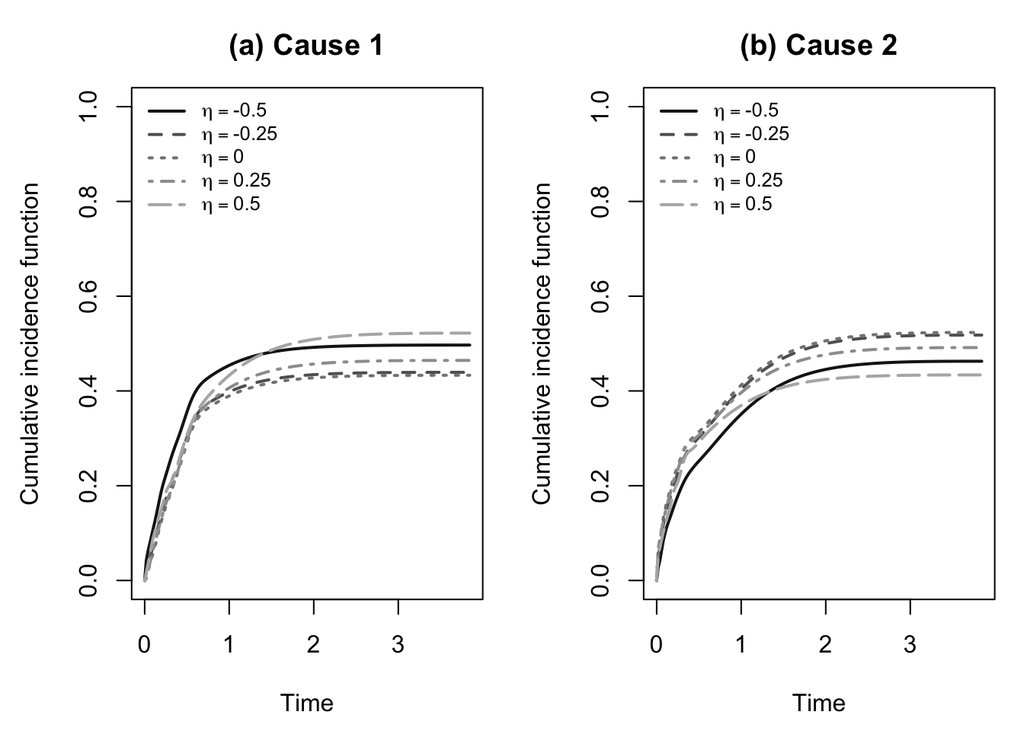

```r
#-----------------------------------------------#
# Plot CIFs for the Five eta Scenarios
#-----------------------------------------------#

library(splines)
library(parallel)

# Sensitivity parameters to test (eta = 0 is the transportability case)
etas <- c(-0.5, -0.25, 0, 0.25, 0.5)

# Define a representative subject profile: each covariate at its sample mean.
Z_subj <- vapply(covariates, function(v) mean(dat_main[[v]], na.rm = TRUE),
                 numeric(1))

# --- Refit bssmle_clustered() across all eta values in parallel ---
num_cores <- max(1, detectCores() - 1)
cl <- makeCluster(num_cores)

clusterExport(cl,
              c("dat_main", "bssmle_clustered", "naive_b", "covariates"),
              envir = environment())
invisible(clusterEvalQ(cl, library(splines)))

fit_eta <- parLapply(cl, etas, function(eta) {
  dat_eta <- dat_main
  eps <- 1e-12
  dat_eta$p21 <- plogis(qlogis(pmin(pmax(dat_eta$p21, eps), 1 - eps)) + eta)
  dat_eta$p12 <- plogis(qlogis(pmin(pmax(dat_eta$p12, eps), 1 - eps)) + eta)
  bssmle_clustered(dat_eta, covariates = covariates)
})

stopCluster(cl)
names(fit_eta) <- paste0("eta_", etas)

# --- Build B-spline basis for the time grid (matches bssmle_clustered's setup) ---
t_fit     <- dat_main$x
nk        <- floor(length(t_fit)^(1/3))
knots_fit <- quantile(t_fit, seq(0, 1, by = 1/(nk + 1)))[2:(nk + 1)]
bkn_fit   <- range(t_fit, na.rm = TRUE)
deg_fit   <- 3
t_grid    <- seq(bkn_fit[1], bkn_fit[2], length.out = 200)
Bpred     <- bs(t_grid, knots = knots_fit, degree = deg_fit,
                intercept = TRUE, Boundary.knots = bkn_fit)
dt        <- c(0, diff(t_grid))

# --- Compute CIFs from a fitted parameter vector ---
# Uses baseline hazard splines and covariate effects to obtain F1(t), F2(t).
compute_cif <- function(res, Bpred, Z_subj, t_grid, dt, q) {
  if (is.null(res) || all(is.na(res))) {
    return(list(F1 = rep(NA_real_, length(t_grid)),
                F2 = rep(NA_real_, length(t_grid))))
  }

  # Number of spline coefficients per cause
  n_phi <- (length(res) - 2 * q) / 2
  if (!is.finite(n_phi) || n_phi != floor(n_phi) || n_phi <= 0) {
    return(list(F1 = rep(NA_real_, length(t_grid)),
                F2 = rep(NA_real_, length(t_grid))))
  }

  phi1 <- res[1:n_phi]
  phi2 <- res[(n_phi + 1):(2 * n_phi)]
  b1   <- res[(2 * n_phi + 1):(2 * n_phi + q)]
  b2   <- res[(2 * n_phi + q + 1):(2 * n_phi + 2 * q)]

  # Cumulative hazards (subject-specific)
  H1 <- as.numeric(exp(Bpred %*% phi1)) * exp(sum(Z_subj * b1))
  H2 <- as.numeric(exp(Bpred %*% phi2)) * exp(sum(Z_subj * b2))

  # Approximate instantaneous hazards via finite differences
  h1 <- c(0, diff(H1)) / dt
  h2 <- c(0, diff(H2)) / dt
  h1[!is.finite(h1)] <- 0
  h2[!is.finite(h2)] <- 0

  # Overall survival and cause-specific CIFs (numerical integration)
  S_t <- exp(-(H1 + H2))
  F1  <- cumsum(S_t * h1 * dt)
  F2  <- cumsum(S_t * h2 * dt)

  list(F1 = F1, F2 = F2)
}

# --- Compute CIFs for every eta value ---
q_cov    <- length(covariates)
cif_list <- lapply(fit_eta, compute_cif,
                   Bpred = Bpred, Z_subj = Z_subj,
                   t_grid = t_grid, dt = dt, q = q_cov)

# --- Plot the CIFs for each cause ---
par(mfrow = c(1, 2), mar = c(4.5, 4.5, 3, 1))
cols <- gray.colors(length(etas), start = 0.1, end = 0.7)

## (a) Cause 1
plot(t_grid, cif_list[[1]]$F1, type = "n", ylim = c(0, 1),
     xlab = "Time", ylab = "Cumulative incidence function",
     main = "(a) Cause 1")
for (i in seq_along(etas)) {
  lines(t_grid, cif_list[[i]]$F1, col = cols[i], lwd = 2, lty = i)
}
legend("topleft", legend = sapply(etas, \(e) bquote(eta == .(e))),
       col = cols, lwd = 2, lty = seq_along(etas),
       bty = "n", cex = 0.8)

## (b) Cause 2
plot(t_grid, cif_list[[1]]$F2, type = "n", ylim = c(0, 1),
     xlab = "Time", ylab = "Cumulative incidence function",
     main = "(b) Cause 2")
for (i in seq_along(etas)) {
  lines(t_grid, cif_list[[i]]$F2, col = cols[i], lwd = 2, lty = i)
}
legend("topleft", legend = sapply(etas, \(e) bquote(eta == .(e))),
       col = cols, lwd = 2, lty = seq_along(etas),
       bty = "n", cex = 0.8)
```

## Concluding remarks

This example demonstrated the use of our **marginal semiparametric regression method for clustered competing risks data with misclassified causes of failure**. Using simulated clustered data, we estimated misclassification probabilities from an external validation sample, applied the `bssmle_clustered()` estimator, and examined sensitivity to the transportability assumption through the parameter $\eta$. The method adjusts for **outcome misclassification** and **informative cluster size**, and **within-cluster dependence** is accounted for in inference through the cluster bootstrap in Step 7, which also propagates the uncertainty in the externally estimated misclassification parameters. Overall, it provides a flexible and practical framework for analyzing real-world clustered competing-risks data where outcome misclassification is likely.

[^1]: Department of Biostatistics and Health Data Science, Fairbanks School of Public Health and School of Medicine, Indiana University Indianapolis, IN, USA
[^2]: Department of Biostatistics and Health Data Science, Fairbanks School of Public Health and School of Medicine, Indiana University Indianapolis, IN, USA
[^3]: Department of Epidemiology and Biostatistics, CUNY Graduate School of Public Health and Health Policy, City University of New York, NY, USA